# A98_W98noNorm_B2L_nz_99FT01q3

Emi

2023-03-30

# 1 Sample specs

```r
# RUN THIS BEFORE KNITTING!!!
# Sam Specs
SS <- read_ods('../Data/sams_specs_BAFA.ods') %>%
  filter(IDSAM == params$IDSAM)
#SS <- read_csv('../Data/sams_specs_BAFA.csv', show_col_types = FALSE) %>% filter(IDSAM == params$IDSAM)
if(NROW(SS) > 1) { stop(paste0("The provided SAMID, ", IDSAM, " is NOT unique!")) }
if(NROW(SS) == 0) { stop(paste0("The provided SAMID, ", IDSAM, " cant be found!")) }

thisVars <- str_split(SS$X.VARS, ", ", simplify=TRUE)[1,] %>%
  str_trim(., side='both')
```

## 1.1 Specs

`W` It is the fixed network.

## 1.2 (Expected) Output

- The vector $\mathbf{a}$ which contains the failure time for each bank in the whole sample.
- Matrix $W$ which could be weighted (only 1 matrix as W) `data(t).X`

The covariates for each bank at each $t$

# 2 LOAD DATA

## 2.1 Bank covariates

```r
banksDB <- haven::read_dta('../data/BAFAannual/failures-1997-2001-annual.dta') %>%
  dplyr::mutate(.,
        fechaQ = quarter(as_date(FECHA_D, origin=ymd('1960-01-01')), with_year=TRUE),
        exitDateQ = quarter(as_date(EXIT_DATE, origin=ymd('1960-01-01')), with_year=TRUE),
        startDateQ = quarter(as_date(FIRST_DATE, origin=ymd('1960-01-01')), with_year=TRUE),
        .after = IDENT)

banks <- banksDB %>%
  mutate(failure = if_else(exitDateQ <= SS$Y.FAILUREHORIZON, 1, 0)) %>%
    drop_na(., any_of(c('failure', thisVars))) %>%
  filter(FECHA_A == SS$X.FROM) %>%
  # ONly private banks
  filter(GRUPO_ID_UNI != 4 & GRUPO_ID_UNI !=5) %>%
  filter(startDateQ<= !!SS$X.BANKBIRTHFROM & exitDateQ >= !!SS$Y.FAILURESINCE)

# Select only entities private and alive on 1997q4
banksAtStart <- banksDB %>%
dplyr::group_by(IDENT) %>%
  summarise('start' = FECHA_A,
            'startDateQ' = min(startDateQ),
            NOMRED = first(NOMRED),
            GRUPO_ID_UNI = first(GRUPO_ID_UNI),
            P_LOANS_ARS_RATE_W = first(P_LOANS_ARS_RATE_W))
excBanks <- filter(banksDB, startDateQ>1997.4) %>%
   summarise(IDENT = min(IDENT), NOMRED = first(NOMRED))
```

I lose `1` banks because a) they don’t have complete observations by 1997.4 (missing P_LOANS_ARS_RATE) or b) they were privatised after 1997q4.

```r
select(excBanks, NOMRED, IDENT)
```

| NOMRED | IDENT |
| --- | --- |
|  | 324 |

Hence I end up with 88 banks.

## 2.2 Network data

```r
dbRelations <- read_dta('../data/interLoans/cen_deu_1997-06_2001_quarterly.dta') %>%
  mutate(FECHA_Q = ( as_date(FECHA_D, origin=ymd("1960-01-01")) %>%
                     tsibble::yearquarter(.) ),
         weight = .data[[ SS$W.WVAR]]*100) %>%
  tsibble(key = c(IDENT_ACREEDORA, IDENT_DEUDORA),
          index = FECHA_Q)
# igraph needs weight in lower case

# W_A_PR W_D_PR
thisRelations <- filter_index(dbRelations, SS$W.FROM ~ SS$W.TO) %>%
  # fechaQ >= 1997.4 &
  filter(., (IDENT_ACREEDORA != IDENT_DEUDORA))
```

```r
descr(thisRelations$weight, round.digits=4)
```

```
## Descriptive Statistics
## thisRelations$weight
## Label: Proporción de prestamos a Préstamos
## N: 1818
##
##                        weight
## ----------------- -----------
##              Mean      1.1836
##           Std.Dev      2.9037
##               Min      0.0000
##                Q1      0.0002
##            Median      0.0504
##                Q3      0.8904
##               Max     20.2503
##               MAD      0.0747
##               IQR      0.8878
##                CV      2.4532
##          Skewness      4.3305
##       SE.Skewness      0.0574
##          Kurtosis     21.9864
##           N.Valid   1815.0000
##         Pct.Valid     99.8350
```

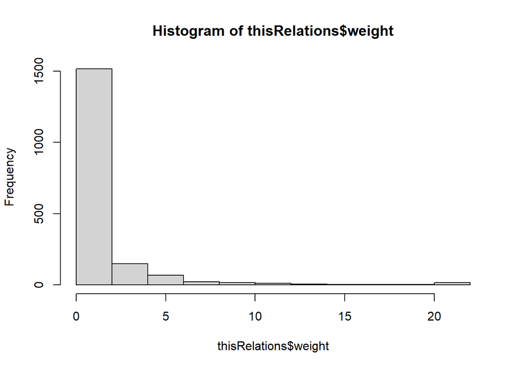

```r
hist(thisRelations$weight)
```

```r
#, breaks=seq(from=0, to=30, by=0.05))
```

```r
thisRelations <- filter(thisRelations, weight > 0 & !is.na(weight))
if (!is.na(SS$W.LINK.WEIGHT.MIN)) {
  thisRelations <- filter(thisRelations, weight > SS$W.LINK.WEIGHT.MIN)
}
```

```r
descr(thisRelations$weight, round.digits = 4)
```

```
## Descriptive Statistics
## thisRelations$weight
## Label: Proporción de prestamos a Préstamos
## N: 1625
##
##                        weight
## ----------------- -----------
##              Mean      1.3220
##           Std.Dev      3.0389
##               Min      0.0000
##                Q1      0.0010
##            Median      0.1320
##                Q3      1.1493
##               Max     20.2503
##               MAD      0.1956
##               IQR      1.1483
##                CV      2.2986
##          Skewness      4.0899
##       SE.Skewness      0.0607
##          Kurtosis     19.5033
##           N.Valid   1625.0000
##         Pct.Valid    100.0000
```

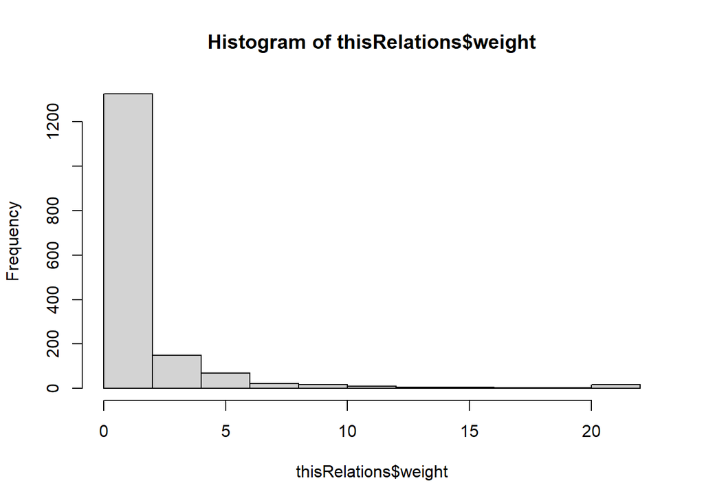

```r
hist(thisRelations$weight)
```

```r
#, breaks=seq(from=0, to=30, by=0.05))
head(thisRelations)
```

| FECHA_Q | FECHA_A | IDENT_ACREEDORA | IDENT_DEUDORA | PRESTAMOS | IDENT | A_ActivoN | A_APRestamos | A_GRUPO_ID_UNI | D_ActivoN | D_APRestamos | D_GRUPO_ID_UNI | _merge | W_A_A | W_A_PR | FECHA_D | W_D_A | W_D_A_w | W_D_PR | W_D_PR_w | weight |
| --- | --- | --- | --- | --- | --- | --- | --- | --- | --- | --- | --- | --- | --- | --- | --- | --- | --- | --- | --- | --- |
| 10408 | 2e+03 | 1 | 15 | 3.5 | 15 | 1.59e+06 | 7.44e+05 | 1 | 9.19e+06 | 4.86e+06 | 6 | 3 | 2.21e-06 | 4.71e-06 | 1998-07-01 | 3.81e-07 | 3.81e-07 | 7.2e-07 | 7.2e-07 | 0.000471 |
| 10408 | 2e+03 | 1 | 293 | 0.3 | 293 | 1.59e+06 | 7.44e+05 | 1 | 7.01e+04 | 4.13e+04 | 3 | 3 | 1.89e-07 | 4.03e-07 | 1998-07-01 | 4.28e-06 | 4.28e-06 | 7.27e-06 | 7.27e-06 | 4.03e-05 |
| 10408 | 2e+03 | 1 | 325 | 591 | 325 | 1.59e+06 | 7.44e+05 | 1 | 2.2e+06 | 2.51e+05 | 1 | 3 | 0.000373 | 0.000795 | 1998-07-01 | 0.000268 | 0.000268 | 0.00236 | 0.00236 | 0.0795 |
| 10227 | 2e+03 | 1 | 4.41e+04 | 1.66e+04 | 4.41e+04 | 1.82e+06 | 1.09e+06 | 1 | 4e+05 | 3.62e+05 | 8 | 3 | 0.00909 | 0.0152 | 1998-01-01 | 0.0414 | 0.0414 | 0.0457 | 0.0457 | 1.52 |
| 10408 | 2e+03 | 1 | 4.41e+04 | 8.03e+03 | 4.41e+04 | 1.59e+06 | 7.44e+05 | 1 | 4.87e+05 | 4.5e+05 | 8 | 3 | 0.00507 | 0.0108 | 1998-07-01 | 0.0165 | 0.0165 | 0.0178 | 0.0178 | 1.08 |
| 10227 | 2e+03 | 1 | 4.41e+04 | 2e+04 | 4.41e+04 | 1.82e+06 | 1.09e+06 | 1 | 3.81e+05 | 3.12e+05 | 8 | 3 | 0.011 | 0.0184 | 1998-01-01 | 0.0525 | 0.0525 | 0.0643 | 0.0643 | 1.84 |

```r
# Number of unique relations (links)
uLinksN <- select(thisRelations, IDENT_ACREEDORA, IDENT_DEUDORA) %>%
  distinct() %>%
  nrow()
```

# 3 BUILD OBJECTS

I build the network first since it will determine which banks are included.

## 3.1 Build the Average Network

$W$ is the average for each link between 1998q1 and 1998q4 for all banks

```r
# Reconvert to tibble because tsibble cannot drop the groupping by time (index)
avgRelations <- thisRelations %>%
  as_tibble(.) %>%
  group_by(IDENT_ACREEDORA, IDENT_DEUDORA) %>%
  summarise(weight = mean(weight)) %>%
  # W can only contains entities that are in the sample.
  # So both, IDENT_ACREEDORA and IDENT_DEUDORA must refer to IDENT that are in banks
  semi_join(., select(banks, IDENT),  by= c('IDENT_ACREEDORA' = 'IDENT')) %>%
  semi_join(., select(banks, IDENT),  by= c('IDENT_DEUDORA' = 'IDENT'))
  #filter(., weight<0.1)
# This dataframe should be empty
netExcBanks <- bind_rows(anti_join(avgRelations, banks, by=c('IDENT_ACREEDORA' = 'IDENT')),
                    anti_join(avgRelations, banks, by=c('IDENT_DEUDORA' = 'IDENT')))

head(avgRelations)
```

```
## # A tibble: 6 × 3
## # Groups:   IDENT_ACREEDORA [1]
##   IDENT_ACREEDORA IDENT_DEUDORA weight
##             <dbl>         <dbl>  <dbl>
## 1               3             6  0.944
## 2               3             7  1.26
## 3               3            16  1.15
## 4               3            34  0.467
## 5               3            67  0.471
## 6               3            72  0.243
```

```r
uLinksN <- select(avgRelations, IDENT_ACREEDORA, IDENT_DEUDORA) %>%
  distinct() %>%
  nrow()
```

There are 639 unique links in the average network `avgRelations`.

You dont want to have a row of zeros (an entitiy with no relationship). If the graph is **directed** based on lender that means that all entities that do not lend should not be in the graph and this in the analysis. If the graph is **undirected** it does not matter.

```r
if(SS$W.DIRECTED == TRUE) {
  if(SS$W.WVAR == "W_A_PR") {
    # lender perspective
    #samRelations <- select(avgRelations, IDENT_ACREEDORA, IDENT_DEUDORA, weight)
    samRelations <- select(avgRelations, IDENT_DEUDORA, IDENT_ACREEDORA, weight)

  } else if (SS$W.WVAR == "W_D_PR") {
    # borrower perspective
    samRelations <- select(avgRelations, IDENT_ACREEDORA, IDENT_DEUDORA, weight)
  }
} else {
  # UNDIRECTED GRAPH, no weight
  samRelations <- select(avgRelations, IDENT_DEUDORA, IDENT_ACREEDORA)
}

nodes <- banks %>%
  select(., IDENT, NOMRED, ActivoN, failure)

network <- igraph::graph_from_data_frame(d = samRelations,
                           vertices = nodes,
                          directed = SS$W.DIRECTED)

summary(network)
```

```
## IGRAPH 39029f2 DNW- 88 639 --
## + attr: name (v/c), NOMRED (v/c), ActivoN (v/n), failure (v/n), weight
## | (e/n)
```

Identify lenders and borrowers

```r
borrowers <- unique(avgRelations$IDENT_DEUDORA)
lenders <- unique(avgRelations$IDENT_ACREEDORA)
banks <- mutate(banks, 'IS_BORROWER' = (IDENT %in% borrowers),
                            'IS_LENDER' = (IDENT %in% lenders))
# The borrower is also a lender
strictLenders <- filter(avgRelations,
                        IDENT_DEUDORA %in% lenders)$IDENT_ACREEDORA %>%
  unique()
# The lender is also a borrower
strictBorrowers <- filter(avgRelations,
                        IDENT_ACREEDORA %in% borrowers)$IDENT_DEUDORA %>%
  unique()
```

```r
G <- network # G may be filtered
excBanksID <- NA
names(excBanksID) <- NA

if (SS$W.ALLOW.ZERO == FALSE) {
  # Delete isolated nodes
  # (its only 1 iteration for undirected graph)

  #edgeMode <- if_else(SS$W.WVAR == 'W_A_PR', 'in', 'out') # out for lenders, in for borrowers
  edgeMode <- 'out' # what matters is wether the node has a row of zeros in W
  # an out mean the bank owns money to othert bank, this its failure can spread. otherwise the failure does not spread
  print(paste0("Prune the graph until all nodes with no ", edgeMode, " edges are removed"))
  isolated = which(degree(G, mode=edgeMode)==0)
  excBanksID <- isolated
  while (length(isolated)>0) {
    G = delete.vertices(G, isolated)
    excBanksID <- c(excBanksID, isolated)

    isolated = which(degree(G, mode=edgeMode)==0)
  }
}
```

```
## [1] "Prune the graph until all nodes with no out edges are removed"
```

```r
# WEIGHTED and UNWEIGHTED W
summary(G)
```

```
## IGRAPH 391113b DNW- 72 584 --
## + attr: name (v/c), NOMRED (v/c), ActivoN (v/n), failure (v/n), weight
## | (e/n)
```

```r
# DIRECTED W
if (SS$W.DIRECTED == TRUE) {
  if(SS$W.WEIGHTED == TRUE) {
    # DIRECTED and Weighted W
    W <- create_adj_matrix(G, weighted=TRUE, row_norm=SS$W.ROW.NORM)
    spatialRegNetwork <-  spdep::mat2listw(W)
    summary(spatialRegNetwork, zero.policy=SS$W.ALLOW.ZERO)
  } else {
    # DIRECTED and Unweighted W
  W <- create_adj_matrix(G, weighted=FALSE, row_norm=SS$W.ROW.NORM)
  spatialRegNetwork <-  spdep::mat2listw(W)
  summary(spatialRegNetwork, zero.policy=SS$W.ALLOW.ZERO)
  }
} else {
# UNDIRECTED W
  # UNDIRECTED and unweighted (only possible when W is undirected)
  W <- create_adj_matrix(G, weighted=FALSE, row_norm=SS$W.ROW.NORM)
  spatialRegNetwork <-  spdep::mat2listw(W)
  summary(spatialRegNetwork, zero.policy=SS$W.ALLOW.ZERO)

}
```

```
## [1] "Weighted network"
## Characteristics of weights list object:
## Neighbour list object:
## Number of regions: 72
## Number of nonzero links: 584
## Percentage nonzero weights: 11.26543
## Average number of links: 8.111111
## Non-symmetric neighbours list
## Link number distribution:
##
##  1  2  3  4  5  6  7  8  9 10 11 12 13 14 15 16 17 18 20 21 22
##  6  9  8  4  5  7  2  2  1  3  3  5  4  1  1  2  2  1  2  2  2
## 6 least connected regions:
## 236 293 315 44019 45072 45085 with 1 link
## 2 most connected regions:
## 16 67 with 22 links
##
## Weights style: M
## Weights constants summary:
##    n   nn       S0       S1       S2
## M 72 5184 799.3122 6283.041 79128.87
```

#### 3.1.0.1 Invertibility: eigenvalues

```r
wEigVals <- tibble('EIG_VAL' = eigen(W, symmetric=(-1)*SS$W.DIRECTED, only.values = TRUE)$values,
                   'REAL_PART' = Re(EIG_VAL),
                    'IM_PART' = Im(EIG_VAL))

any(abs(wEigVals$REAL_PART) >= 1)
```

```
## [1] TRUE
```

```r
wEigVals %>%
  datatable(.)
```

|  | EIG_VAL | REAL_PART | IM_PART |
| --- | --- | --- | --- |
| 1 | 20.7411970126857 | 20.7411970126857 | 0 |
| 2 | 14.061987062218 | 14.061987062218 | 0 |
| 3 | 12.0958807533837 | 12.0958807533837 | 0 |
| 4 | 10.1712731850052 | 10.1712731850052 | 0 |
| 5 | 6.3069462018925 | 6.3069462018925 | 0 |
| 6 | 6.00486759826385 | 6.00486759826385 | 0 |
| 7 | 5.6807127842427 | 5.6807127842427 | 0 |
| 8 | 4.73972895117407 | 4.73972895117407 | 0 |
| 9 | 3.8975147007541 | 3.8975147007541 | 0 |
| 10 | 3.28511451371397 | 3.28511451371397 | 0 |

[output cut: 62 more lines]

```r
eigRealMin <- filter(wEigVals, IM_PART == 0)$REAL_PART %>%
  min(.)
rhoMin <- 1/eigRealMin
```

As shown in [p88-89]{LeSagePace2009book} shows that the condition for invertibility only depends on the **real** eigenvalues such that $\rho$ is restricted to be in the interval ($r^{-1}_{\text{min}}, 1$) where $r^{-1}_{\text{min}}$ is the smallest-pure-real eigenvalue of $W$. The smallest-pure-real eigenvalue is -20.5437248 and thus
$$\rho \in ( -0.0486767, 1)$$

Eigenvalues and max row and column sum for $W_0$ the original W before row-normalisation

```r
if (SS$W.DIRECTED == TRUE) {
  W0 <- as_adjacency_matrix(network, attr='weight', sparse=FALSE)
} else {
  W0 <- as_adjacency_matrix(network, sparse=FALSE)
}

w0EigVals <- tibble('eigenVals' = eigen(W0,
                                       symmetric=(-1)*SS$W.DIRECTED, only.values = TRUE)$values)

any(abs(w0EigVals$eigenVals) >= 1)
```

```
## [1] TRUE
```

```r
w0EigVals %>%
  datatable(.)
```

|  | eigenVals |
| --- | --- |
| 1 | 21.0498000785574 |
| 2 | 14.5115298728654 |
| 3 | 12.1250119933445 |
| 4 | 10.4229243076154 |
| 5 | 7.26975130614606 |
| 6 | 6.35585124436352 |
| 7 | 5.88881312298487 |
| 8 | 4.82987668962501 |
| 9 | 4.26852490376789 |
| 10 | 3.87567422489303 |

[output cut: 78 more lines]

```r
# when is (I - rhoW) non-singular for all |\rho|< 1/\alpha
W0rowSum <- Matrix::rowSums(W0)
W0colSum <- Matrix::colSums(W0)
alpha = min(max(W0rowSum), max(W0colSum))
```

If W is not row-normalised, Keleijian & Piras (2017) establishes that
$$(I_N - \rho W), \text{ is non-singular for all } |\rho| < 1/\alpha.$$
where $\alpha = min(r, c)$ and $r$ is the maximum sum for a row, and $c$ the maximum sum for a column.

The maximum row sum for $W_0$ is 60.3911964 and the maximum colum sum for $W_0$ is 158.669783. Then $(I_N - \rho W)$ is not-singular if $| \rho |< 0.017$.

These banks are excluded because they don’t borrow and/or lend.

```r
ExcBanks <- filter(banks, IDENT %in% as.integer(names(excBanksID))) %>%
    select(IDENT, NOMRED, EXIT_DATE, failure, IS_BORROWER, IS_LENDER)

ExcBanks %>%
  datatable(.)
```

|  | IDENT | NOMRED | EXIT_DATE | failure | IS_BORROWER | IS_LENDER |
| --- | --- | --- | --- | --- | --- | --- |
| 1 | 10 | LLOYDS BANK LTD | 2099-12-31 | 0 | False | True |
| 2 | 39 | CAJA AHORRO SA | 1999-08-01 | 1 | False | True |
| 3 | 54 | COM ISRAELITA | 1999-10-01 | 1 | False | True |
| 4 | 113 | EDIF. OLAVARRIA | 2002-06-19 | 0 | False | True |
| 5 | 149 | COFIRENE | 1999-01-28 | 1 | False | False |
| 6 | 165 | MORGAN GUARANTY | 2099-12-31 | 0 | False | True |
| 7 | 231 | RIO TERCERO | 1999-03-31 | 1 | False | False |
| 8 | 44032 | FIN Y MANDATOS | 1999-07-02 | 1 | False | False |
| 9 | 45056 | MONTEMAR CFSA | 2099-12-31 | 0 | False | False |
| 10 | 45065 | MASVENTAS SACF | 2099-12-31 | 0 | False | True |

[output cut: 6 more lines]

```r
uLinksN <- length(E(G))
nLenders <- samRelations %>% ungroup() %>% summarise(n=n_distinct(IDENT_ACREEDORA)) %>% .$n
nBorrowers <- samRelations %>% ungroup() %>% summarise(n=n_distinct(IDENT_DEUDORA)) %>% .$n
```

## 3.2 Build X and Y

Y is the failure vector, X the covariates vector

```r
samBanks <- filter(banks, !(IDENT %in% ExcBanks$IDENT))
nBanks <- samBanks %>% summarise(n=n_distinct(IDENT)) %>% .$n
if(length(V(G)) != nBanks) { stop("The # of banks in samBanks is not the same as the # of vertex in the graph") }

X <- samBanks %>% select(all_of(thisVars))

# 1: failure, 0: survival during the sample period
y <- if_else(samBanks$exitDateQ <= SS$Y.FAILUREHORIZON, 1, 0)
```

There are 69 lenders, 74 borrowers and 584 unique linkes (edges) in the sample network (the final one). There are 72 entities in `samBank`.

There are 639 links in `samRelations`; 584 of them are unique. `W` is 72 $\times$ 72 and the number of banks in `samBanks` is 72. They should be equal!

The following entities appear in the network but not in the banks dataframe: NROWS: 0. Should be empty! Mean weight is 1.3719482

## 3.3 Desc stats

### 3.3.1 Banks

> The number of failures is **14**

```r
descStatsT <- dplyr::bind_cols('y'=y, X, 'IDENT'=samBanks$IDENT) %>%
  descStats2(.)
  descStatsT %>%
    datatable() %>%
    formatRound(columns=c('min', 'median', 'mean', 'SD', 'max', 'CV'))
```

|  | variable | min | median | mean | SD | max | CV | numObs |
| --- | --- | --- | --- | --- | --- | --- | --- | --- |
| 1 | y | 0 | 0 | 0.194444444444444 | 0.398549796803463 | 1 | 2.04968466927495 | 72 |
| 2 | ActivoN | 20954.25 | 358058.203125 | 1341706.84236654 | 2540281.41710753 | 12020002 | 1.89332075897215 | 72 |
| 3 | C8Est_w | 4.38113164901733 | 12.2368097305298 | 15.807126502196 | 11.0944019534451 | 59.664363861084 | 0.701860768426435 | 72 |
| 4 | CAR_IRR_3A6 | 0 | 7.19250011444092 | 7.65921345187558 | 5.47019762378211 | 25.4072723388672 | 0.714198351848071 | 72 |
| 5 | P_ROA | -8.11909103393555 | 0.604999989271164 | 0.91502987078598 | 2.83399544159035 | 14.3099994659424 | 3.09716166878361 | 72 |
| 6 | P_DEP_ARS_RATE | 0 | 4.783282995224 | 5.19596287980676 | 2.9047827148069 | 13.9549999237061 | 0.559046086740892 | 72 |
| 7 | P_LOANS_ARS_RATE_W | 6.52600002288818 | 21.7159090042114 | 23.3572915130191 | 9.46447280406803 | 46.7319984436035 | 0.405204207807768 | 72 |
| 8 | APRSpNF_RATE_W | 0 | 0 | 4.18620171826888 | 8.20961422481573 | 37.2909851074219 | 1.96111290791086 | 72 |
| 9 | APR_USD_RATE | 1.33263504505157 | 60.2731475830078 | 57.8795570615265 | 22.3929606081379 | 99.9816970825195 | 0.386888942227632 | 72 |
| 10 | APR_RATE_W | 5.78186941146851 | 52.9009628295898 | 51.1765106320381 | 17.4894244173085 | 90.694221496582 | 0.341747106266357 | 72 |

[output cut: 1 more lines]

### 3.3.2 Network

```r
summary(spatialRegNetwork, zero.policy=SS$W.ALLOW.ZERO)
```

```
## Characteristics of weights list object:
## Neighbour list object:
## Number of regions: 72
## Number of nonzero links: 584
## Percentage nonzero weights: 11.26543
## Average number of links: 8.111111
## Non-symmetric neighbours list
## Link number distribution:
##
##  1  2  3  4  5  6  7  8  9 10 11 12 13 14 15 16 17 18 20 21 22
##  6  9  8  4  5  7  2  2  1  3  3  5  4  1  1  2  2  1  2  2  2
## 6 least connected regions:
## 236 293 315 44019 45072 45085 with 1 link
## 2 most connected regions:
## 16 67 with 22 links
##
## Weights style: M
## Weights constants summary:
##    n   nn       S0       S1       S2
## M 72 5184 799.3122 6283.041 79128.87
```

# 4 Test a linear SAR

```r
model <- spatialreg::lagsarlm(formula ='y ~ log(ActivoN) + C8Est_w+ CAR_IRR_3A6+ P_ROA+ P_DEP_ARS_RATE +
  P_LOANS_ARS_RATE_W+ APRSpNF_RATE_W+ APR_USD_RATE+ APR_RATE_W',
        data = bind_cols('y'=y, X),
        listw = spatialRegNetwork,
        zero.policy = SS$W.ALLOW.ZERO)

regSumm <- summary(model)

regSumm
```

```
##
## Call:
## spatialreg::lagsarlm(formula = "y ~ log(ActivoN) + C8Est_w+ CAR_IRR_3A6+ P_ROA+ P_DEP_ARS_RATE +\n  P_LOANS_ARS_RATE_W+ APRSpNF_RATE_W+ APR_USD_RATE+ APR_RATE_W",
##     data = bind_cols(y = y, X), listw = spatialRegNetwork, zero.policy = SS$W.ALLOW.ZERO)
##
## Residuals:
##       Min        1Q    Median        3Q       Max
## -0.442413 -0.224396 -0.134533  0.043972  0.856945
##
## Type: lag
## Coefficients: (asymptotic standard errors)
##                       Estimate  Std. Error z value Pr(>|z|)
## (Intercept)         1.2941e+00  5.6822e-01  2.2774  0.02276
## log(ActivoN)       -8.4767e-02  3.7332e-02 -2.2706  0.02317
## C8Est_w            -1.0573e-02  5.2477e-03 -2.0147  0.04393
## CAR_IRR_3A6         4.0695e-03  9.9190e-03  0.4103  0.68161
## P_ROA              -9.5984e-03  1.9051e-02 -0.5038  0.61438
## P_DEP_ARS_RATE     -7.1826e-03  1.5326e-02 -0.4686  0.63933
## P_LOANS_ARS_RATE_W -2.0566e-05  6.7232e-03 -0.0031  0.99756
## APRSpNF_RATE_W     -5.7655e-03  5.7930e-03 -0.9953  0.31961
## APR_USD_RATE        3.6191e-03  2.6082e-03  1.3876  0.16526
## APR_RATE_W          2.4254e-04  2.9023e-03  0.0836  0.93340
##
## Rho: -0.010588, LR test value: 0.81074, p-value: 0.3679
## Asymptotic standard error: 0.010309
##     z-value: -1.0271, p-value: 0.30439
## Wald statistic: 1.0549, p-value: 0.30439
##
## Log likelihood: -28.67939 for lag model
## ML residual variance (sigma squared): 0.12985, (sigma: 0.36035)
## Number of observations: 72
## Number of parameters estimated: 12
## AIC: 81.359, (AIC for lm: 80.17)
## LM test for residual autocorrelation
## test value: 0.53911, p-value: 0.4628
```

# 5 SAVE

## 5.1 Sample

```r
fileName <- paste0('../', SS$SAMSAVINGFOLDER, SS$IDSAM, '.rds')

if (file.exists(fileName)) {
  warning('the file already exists. I dont overwrite it')
} else {
  saveRDS(list('y'=y, 'X'=X, 'G'=G, 'W'=W,
               'samBanks'=samBanks, 'specs'=SS),
        file=fileName)
}
```